**Zachary Richardson**

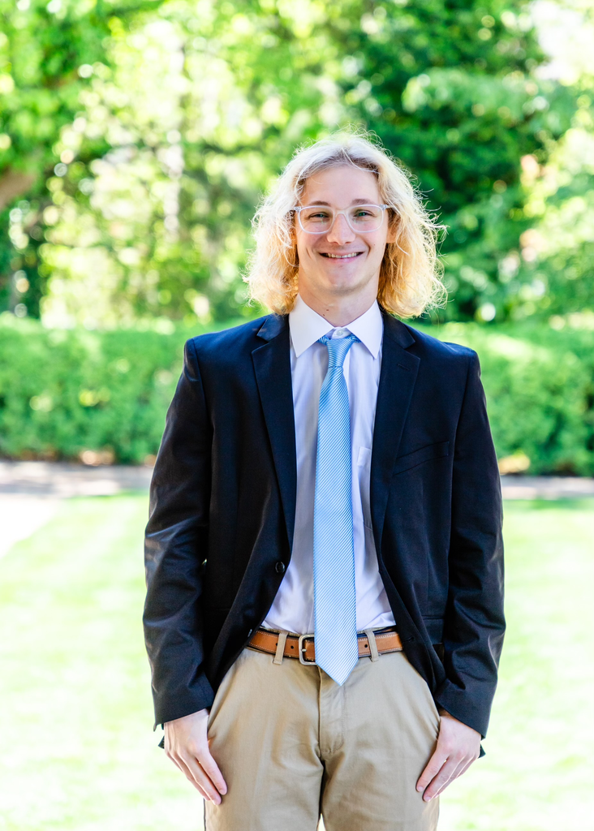

Email: Richardson.ZacharyH@gmail.com | Phone: (252) 266-9212 | [LinkedIn](https://www.linkedin.com/in/zachary-richardson24/) | [GitHub](https://github.com/zachary-richardson16)

## Mission Statement

I am a passionate and driven data scientist looking to apply my vast analytical experiences and knowledge to the world of sports analytics. My goal is to use a data-driven approach to provide competitive advantages to professional sports teams, identify new and innovative trends in sports analytics, and make a meaningful impact on the analytics industry as a whole.

## Overview

### Education

#### **Institute for Advanced Analytics, North Carolina State University** – Raleigh, NC | May 2026

*Master of Science in Analytics*

#### **University of North Carolina at Chapel Hill** – Chapel Hill, NC | May 2024

*Bachelor of Science in Biology, Minors in Data Science and Statistics*

#### **Relevant Coursework**

*Foundations of Statistics and Data Science, Introduction to Probability, Methods of Data Analysis, Sports Analytics*

#### **North Carolina School of Science and Mathematics** – Durham, NC | May 2020

### Experience

#### **Oklahoma City Thunder (NBA)** - Oklahoma City, OK (Remote) | September 2024-May 2025

*Analyst Intern*

- Simplified and improved predictiveness of a player evaluation model using techniques including ordinal logistic regression and random forest
- Developed an extensive audit function that provides an easy way of interpreting model prediction errors and avenues for improvement
- Created an interactive HTML document that utilizes the audit function to allow for visualization of players via sorting, filtering, and/or grouping by various metrics
- Shared thoughts and feedback with peers weekly in a brief but insightful manner that quickly summarized key findings, issues, and next steps

#### **Pro Football Focus** - Cincinnati, OH (Remote) | May 2024-July 2024

*Data Collector Trainee*

- Studied college and NFL game film to collect precise data including play-by-play player position and role

#### **UNC Baseball Analytics Team** – Chapel Hill, NC | September 2023-June 2024

*Data Analyst*

- Create weekly pitcher reports including detailed visuals such as pitch heat maps, spin axis diagrams, and player game logs
- Perform full stack development of team R Shiny application to enhance user experience through improved readability of pitcher ranking tables and streamline R script functions for managing app data
- Collect, clean, and manage pitcher and hitter data using Trackman software, manual pitch tagging via 2-dimensional velocity and break statistics, and AWS

#### **Carolina Athletics** – Chapel Hill, NC | August 2023-December 2023

*Data Analytics Intern*

- Extracted, cleaned, and merged large data sets using SQL, resulting in enhanced data accuracy and streamlined decision-making processes
- Conducted email market analysis on over 1,000,000 emails using Tableau to identify patterns in emails leading to high profitability and optimized ticket revenue generation
- Conducted and presented weekly research on current analytical trends and advanced visualization techniques in sports analytics

### Projects

#### Collaborative

[NBA Predictions](https://github.com/zachary-richardson16/stor538-prediction-project)

- Group project for UNC course *Sports Analytics* focused on predicting NBA point totals, spread, and offensive rebound totals for the final week of the regular season

[FIFA 21](https://github.com/zachary-richardson16/FIFA-Analysis)

- Final project for UNC course *Introduction to Data Science* analyzing data from the video game FIFA 21

[9 Ball Pool](https://github.com/zachary-richardson16/9-Ball-Analysis)

- Group project for UNC course *Sports Analytics* where we watched 9 ball pool videos, collected data, and performed analysis to identify a potential competitive edge for players of the sport

[Cincinnati Reds Hackathon](https://github.com/zachary-richardson16/reds-hackathon)

- 2024 Cincinnati Reds Hackathon submission – analysis of every MLB pitch from 2021-2023 and Fangraphs data to identify several MLB pitchers who would be better suited in an alternative pitching role than the one they played in the 2023 season

#### Independent

[NBA Assisted Shot Analysis](https://github.com/zachary-richardson16/nba-assisted-shots-analysis)

- Analysis of which areas on the court are most impacted by assists, valuable for identifying catch-and-shoot locations and useful for play design
- Currently in progress – data collection

[Personal Website](https://github.com/zachary-richardson16/personal-website)

- My personal website (which you are currently viewing) detailing my experiences and a few projects that I have worked on

[NBA Shot Charts](https://github.com/zachary-richardson16/nba-shot-charts)

- Collection of NBA player game, season, and career shot charts drawn using `ggplot` package in R